# Reproducibility Review AGILE 2022

Daniel Nüst

10 May, 2022

## Introduction

This document includes scripts and text analysis to support the reproducibility review at the [AGILE conference 2022](https://agile-online.org/conference-2022), which is organised by a team from Vilnius, Lithuania.

Find out more online [about reproducible publications at AGILE](https://doi.org/10.17605/OSF.IO/PHMCE) and the [review process](https://osf.io/eg4qx/), and visit the Reproducible AGILE website: https://reproducible-agile.github.io/. The code of this document is published on GitHub in the repository reproducible-agile/reviews-2022, where you can inspect the R code in the file `agile-reproducibility-reviews.Rmd` and find instructions for reproducing the workflow. The [report parameter](https://bookdown.org/yihui/rmarkdown/parameterized-reports.html) `private_info` can be set to `yes` to show information which cannot be shared publicly, such as author names, titles, or excerpts of not accepted submissions, and to upload review files to private shares, which requires authentication.

```r
if(is.na(Sys.getenv("easychair_username", unset = NA)) || is.na(Sys.getenv("easychair_password", unset = NA))) {
  stop("Provide login details for EasyChair (e.g., in a file `.Renviron` - make sure to adjust read persmissions so that no user but you/root may access the file!) in environment variables",
       "`easychair_username` and `easychair_password`")
}

# with help from https://github.com/kaytwo/easierchair/blob/master/scrape_easychair.py
# https://stackoverflow.com/questions/23202522/r-httr-post-request-for-signing-in
login_response <- NULL
if(is.null(login_response)) {
  login_response <- httr::POST(url = "https://easychair.org/account/verify",
                         body = list(name = Sys.getenv("easychair_username"),
                                     password = Sys.getenv("easychair_password")),
                         encode = "form")
}
```

## Submitted papers

### Submission metadata

Retrieve all information about submissions from the EasyChair submissions system. The full submission information is not included in the public rendering of this report. Make sure that the shown columns in the submission table include the colums required in the code below.

| type | n |
| --- | --- |
| Full-paper submission | 24 |
| Short-paper submission | 53 |

| id | authors | title | information | paper | assigment | update | time | decision | type | submission_id |
| --- | --- | --- | --- | --- | --- | --- | --- | --- | --- | --- |
| 003 | Pengxiang Zhao, Aoyong Li, Petter Pilesjö and Ali Mansourian | A machine learning based approach for predicting usage efficiency of shared e-scooters using vehicle availability data | https://easychair.org/conferences/submission_view?a=28425498;submission=5833597 | https://easychair.org/conferences/submission_download?a=28425498;submission=5833597;upload=119385 | NA | NA | Feb 03, 15:31 | ACCEPT | Full-paper submission | 5833597 |
| 004 | Hiroyuki Kaneko and Toshihiro Osaragi | Classifying pedestrian trajectories by Machine learning using laser sensor data | https://easychair.org/conferences/submission_view?submission=5836890;a=28425498 | https://easychair.org/conferences/submission_download?submission=5836890;upload=119385;a=28425498 | NA | NA | Feb 07, 01:53 | ACCEPT | Full-paper submission | 5836890 |
| 005 | Jean-Marie Favreau and Jérémy Kalsron | What are intersections for pedestrian users? | https://easychair.org/conferences/submission_view?a=28425498;submission=5838467 | https://easychair.org/conferences/submission_download?a=28425498;upload=119385;submission=5838467 | NA | NA | Feb 07, 22:23 | ACCEPT | Full-paper submission | 5838467 |
| 006 | Eva Nuhn, Franziska König and Sabine Timpf | “Landmark Route”: A Comparison to the Shortest Route | https://easychair.org/conferences/submission_view?submission=5838884;a=28425498 | https://easychair.org/conferences/submission_download?a=28425498;upload=119385;submission=5838884 | NA | NA | Feb 08, 07:25 | ACCEPT | Full-paper submission | 5838884 |
| 007 | Nina Wiedemann, Henry Martin and Martin Raubal | Unlocking social network analysis methods for studying human mobility | https://easychair.org/conferences/submission_view?submission=5854892;a=28425498 | https://easychair.org/conferences/submission_download?a=28425498;upload=119385;submission=5854892 | NA | NA | Feb 16, 11:00 | ACCEPT | Full-paper submission | 5854892 |
| 008 | Lasith Niroshan and James Carswell | Machine Learning with Kay | https://easychair.org/conferences/submission_view?a=28425498;submission=5856283 | https://easychair.org/conferences/submission_download?upload=119385;submission=5856283;a=28425498 | NA | NA | Feb 17, 13:13 | ACCEPT | Full-paper submission | 5856283 |
| 009 | Frederika Welle Donker, Bastiaan Van Loenen, Carsten Keßler, Natalie Küppers, Mark Panek, Ali Mansourian, Pengxiang Zhao, Glenn Vancauwenberghe, Hrvoje Tomić and Karlo Kević | Showcase of Active Learning and Teaching Practices in Spatial Data Infrastructure (SDI) Education | https://easychair.org/conferences/submission_view?submission=5862956;a=28425498 | https://easychair.org/conferences/submission_download?a=28425498;upload=119385;submission=5862956 | NA | NA | Feb 21, 15:07 | ACCEPT | Full-paper submission | 5862956 |
| 010 | Haojun Cai, Yanan Xin, Henry Martin and Martin Raubal | Optimizing Electric Vehicle Charging Schedules Based on Probabilistic Forecast of Individual Mobility | https://easychair.org/conferences/submission_view?submission=5863719;a=28425498 | https://easychair.org/conferences/submission_download?a=28425498;upload=119385;submission=5863719 | NA | NA | Feb 22, 00:40 | ACCEPT | Full-paper submission | 5863719 |
| 011 | Stefania Zourlidou, Jens Golze and Monika Sester | Traffic Regulation Recognition using Crowd-Sensed GPS and Map Data: a Hybrid Approach | https://easychair.org/conferences/submission_view?a=28425498;submission=5864439 | https://easychair.org/conferences/submission_download?upload=119385;submission=5864439;a=28425498 | NA | NA | Feb 22, 12:34 | ACCEPT | Full-paper submission | 5864439 |
| 012 | Ditsuhi Iskandaryan, Silvana Di Sabatino, Francisco Ramos and Sergio Trilles | Exploratory Analysis and Feature Selection for the Prediction of Nitrogen Dioxide | https://easychair.org/conferences/submission_view?a=28425498;submission=5864480 | https://easychair.org/conferences/submission_download?a=28425498;upload=119385;submission=5864480 | NA | NA | Feb 22, 13:15 | ACCEPT | Full-paper submission | 5864480 |
| 013 | Marina Georgati, João Monteiro, Bruno Martins and Carsten Keßler | Spatial Disaggregation of Population Subgroups Leveraging Self-Trained Multi-Output Gradient Boosted Regression Trees | https://easychair.org/conferences/submission_view?submission=5864635;a=28425498 | https://easychair.org/conferences/submission_download?a=28425498;submission=5864635;upload=119385 | NA | NA | Feb 22, 15:24 | ACCEPT | Full-paper submission | 5864635 |
| 014 | Syed Mehtab Alam, Elena Arsevska, Mathieu Roche and Maguelonne Teisseire | GeoXTag: Relative Spatial Information Extraction and Tagging of Unstructured Text | https://easychair.org/conferences/submission_view?submission=5864717;a=28425498 | https://easychair.org/conferences/submission_download?upload=119385;submission=5864717;a=28425498 | NA | NA | Feb 22, 16:13 | ACCEPT | Full-paper submission | 5864717 |
| 015 | Marie-Dominique Van Damme and Ana-Maria Olteanu-Raimond | A method to produce metadata describing and assessing the quality of spatial landmark datasets in mountain area | https://easychair.org/conferences/submission_view?a=28425498;submission=5865024 | https://easychair.org/conferences/submission_download?submission=5865024;upload=119385;a=28425498 | NA | NA | Feb 22, 21:40 | ACCEPT | Full-paper submission | 5865024 |
| 016 | Hyesop Shin, Costanza Cagnina and Anahid Basiri | The Impact of Built Environment on Bike Commuting: Utilising Strava Bike Data and Geographically Weighted Models | https://easychair.org/conferences/submission_view?a=28425498;submission=5865026 | https://easychair.org/conferences/submission_download?submission=5865026;upload=119385;a=28425498 | NA | NA | Feb 22, 21:46 | ACCEPT | Full-paper submission | 5865026 |
| 017 | Tom Niers, Jan Stenkamp, Nick Pascal Jakuschona, Thomas Bartoschek and Sven Schade | Benchmarking Invasive Alien Species Image Recognition Models for a Citizen Science Based Spatial Distribution Monitoring | https://easychair.org/conferences/submission_view?a=28425498;submission=5865034 | https://easychair.org/conferences/submission_download?upload=119385;submission=5865034;a=28425498 | NA | NA | Feb 22, 21:58 | ACCEPT | Full-paper submission | 5865034 |
| 018 | Thomas Bartoschek and Schwering Angela | Geotechnology-based Spatial Learning: The Effects on Spatial Abilities and Sketch Maps in an Inter-Cultural Study | https://easychair.org/conferences/submission_view?submission=5865062;a=28425498 | https://easychair.org/conferences/submission_download?submission=5865062;upload=119385;a=28425498 | NA | NA | Feb 22, 22:47 | ACCEPT | Full-paper submission | 5865062 |
| 019 | Zilong Liu, Krzysztof Janowicz, Ling Cai, Rui Zhu, Gengchen Mai and Meilin Shi | Geoparsing: Solved or Biased? An Evaluation of Geographic Biases in Geoparsing | https://easychair.org/conferences/submission_view?submission=5865075;a=28425498 | https://easychair.org/conferences/submission_download?submission=5865075;upload=119385;a=28425498 | NA | NA | Feb 22, 23:00 | ACCEPT | Full-paper submission | 5865075 |
| 020 | Rui Zhu, Krzysztof Janowicz, Gengchen Mai, Ling Cai and Meilin Shi | COVID-Forecast-Graph: An Open Knowledge Graph for Consolidating COVID-19 Forecasts and Economic Indicators via Place and Time | https://easychair.org/conferences/submission_view?submission=5865082;a=28425498 | https://easychair.org/conferences/submission_download?a=28425498;upload=119385;submission=5865082 | NA | NA | Feb 22, 23:16 | ACCEPT | Full-paper submission | 5865082 |
| 021 | Pankajeshwara Nand Sharma, Michael Govorov and Nick Rollings | A Usable Encryption Solution for File-based Spatial Data Within a Database File System | https://easychair.org/conferences/submission_view?submission=5868024;a=28425498 | https://easychair.org/conferences/submission_download?a=28425498;submission=5868024;upload=119385 | NA | NA | Feb 25, 03:58 | ACCEPT | Full-paper submission | 5868024 |
| 022 | Yousef Qamaz, Angela Schwering and Janina Bistron | Experimental evaluation of using BLE beacon for outdoor positioning in GPS-denied environment | https://easychair.org/conferences/submission_view?a=28425498;submission=5889379 | https://easychair.org/conferences/submission_download?a=28425498;upload=119385;submission=5889379 | NA | NA | Mar 08, 18:14 | ACCEPT | Full-paper submission | 5889379 |
| 023 | Arun Sharma, Majid Farhadloo, Yan Li, Aditya Kulkarni, Jayant Gupta and Shashi Shekhar | Understanding COVID-19 Effects on Mobility: A Community-Engaged Approach | https://easychair.org/conferences/submission_view?submission=5889451;a=28425498 | https://easychair.org/conferences/submission_download?upload=119385;submission=5889451;a=28425498 | NA | NA | Mar 08, 19:03 | ACCEPT | Full-paper submission | 5889451 |
| 024 | Guoray Cai and Yimu Pan | Understanding the Imperfection of 3D point Cloud and Semantic Segmentation algorithms for 3D Models of Indoor Environment | https://easychair.org/conferences/submission_view?submission=5889639;a=28425498 | https://easychair.org/conferences/submission_download?a=28425498;submission=5889639;upload=119385 | NA | NA | Mar 08, 23:10 | ACCEPT | Full-paper submission | 5889639 |
| 026 | Krzysztof Janowicz, Rui Zhu, Grant McKenzie, Judith Verstegen, Bruno Martins and Ling Cai | Six GIScience Ideas That Must Die | https://easychair.org/conferences/submission_view?submission=5889979;a=28425498 | https://easychair.org/conferences/submission_download?a=28425498;upload=119385;submission=5889979 | NA | NA | Mar 09, 08:03 | ACCEPT | Full-paper submission | 5889979 |
| 027 | Giedrė Beconytė, Andrius Balčiūnas, Inga Andriuškevičiūtė and Živilė Jakubkaitė | Lithuanian spatial information infrastructure: 20 years of evolution, milestones, costs and benefits | https://easychair.org/conferences/submission_view?a=28425498;submission=5937396 | https://easychair.org/conferences/submission_download?submission=5937396;upload=119385;a=28425498 | NA | NA | Apr 05, 19:06 | ACCEPT | Full-paper submission | 5937396 |
| 028 | Jaskaran Singh Puri and Andre Kotze | Evaluation of SRGAN Algorithm for Superresolution of Satellite Imagery on Different Sensors | https://easychair.org/conferences/submission_view?submission=5940799;a=28425498 | https://easychair.org/conferences/submission_download?a=28425498;upload=119385;submission=5940799 | NA | NA | Apr 08, 08:52 | ACCEPT | Short-paper submission | 5940799 |
| 029 | Azelle Courtial, Guillaume Touya and Xiang Zhang | Representing Vector Geographic Information As a Tensor for Deep Learning Based Map Generalisation | https://easychair.org/conferences/submission_view?submission=5941138;a=28425498 | https://easychair.org/conferences/submission_download?upload=119385;submission=5941138;a=28425498 | NA | NA | Apr 08, 11:19 | ACCEPT | Short-paper submission | 5941138 |
| 030 | Sebastian T. Brinkmann, Dominik Kremer and Blake B. Walker | Modelling eye-level visibility of urban green space: Optimising city-wide point-based viewshed computations through prototyping | https://easychair.org/conferences/submission_view?a=28425498;submission=5941602 | https://easychair.org/conferences/submission_download?a=28425498;submission=5941602;upload=119385 | NA | NA | Apr 08, 14:55 | ACCEPT | Short-paper submission | 5941602 |
| 031 | Arend Ligtenberg, Monique Simons, Marjolein Barhorst and Laura Winkens | Making Space a better Place: Just In Time Adaptive Interventions for Healthy Lifestyles | https://easychair.org/conferences/submission_view?submission=5941645;a=28425498 | https://easychair.org/conferences/submission_download?a=28425498;submission=5941645;upload=119385 | NA | NA | Apr 08, 15:22 | ACCEPT | Short-paper submission | 5941645 |
| 032 | Kevin Kocon, Michel Krämer and Hendrik M. Würz | Comparison of CNN-based segmentation models for forest type classification | https://easychair.org/conferences/submission_view?a=28425498;submission=5946212 | https://easychair.org/conferences/submission_download?a=28425498;upload=119385;submission=5946212 | NA | NA | Apr 11, 11:48 | ACCEPT | Short-paper submission | 5946212 |
| 033 | Vicente Tang, Jaskaran Puri and Marco Painho | Mapping a historic neighbourhood through user-generated content: the case of Alfama, Lisbon (Portugal) | https://easychair.org/conferences/submission_view?submission=5946300;a=28425498 | https://easychair.org/conferences/submission_download?a=28425498;submission=5946300;upload=119385 | NA | NA | Apr 11, 12:39 | ACCEPT | Short-paper submission | 5946300 |
| 034 | Yunya Gao, Getachew Gella and Nianhua Liu | Assessing the Influences of Band Selection and Pretrained Weights on Semantic-Segmentation-Based Refugee Dwelling Extraction from Satellite Imagery | https://easychair.org/conferences/submission_view?a=28425498;submission=5946533 | https://easychair.org/conferences/submission_download?upload=119385;submission=5946533;a=28425498 | NA | NA | Apr 11, 15:14 | ACCEPT | Short-paper submission | 5946533 |
| 035 | Jesus Rodrigo Cedeno Jimenez, Pengxiang Zhao, Ali Mansourian and Maria Antonia Brovelli | Geoblockchain: Decentralized geospatial data sharing systems | https://easychair.org/conferences/submission_view?a=28425498;submission=5946637 | https://easychair.org/conferences/submission_download?a=28425498;submission=5946637;upload=119385 | NA | NA | Apr 11, 16:06 | ACCEPT | Short-paper submission | 5946637 |
| 036 | Masoume Mahboubi, Astrid Grønbæk, Ana Fernandes, Casper Fibæk and Paolo Dabove | Geospatial Analysis of Safe Delivery App Events Based on Geographically Weighted Regression Tool. | https://easychair.org/conferences/submission_view?a=28425498;submission=5946689 | https://easychair.org/conferences/submission_download?a=28425498;upload=119385;submission=5946689 | NA | NA | Apr 11, 16:40 | ACCEPT | Short-paper submission | 5946689 |
| 037 | Andreas Georg Wallner, Thomas Piechl, Gernot Paulus and Karl-Heinrich Anders | Open source vector tile creation for spatial data infrastructure applications | https://easychair.org/conferences/submission_view?a=28425498;submission=5946702 | https://easychair.org/conferences/submission_download?upload=119385;submission=5946702;a=28425498 | NA | NA | Apr 11, 16:49 | ACCEPT | Short-paper submission | 5946702 |
| 038 | Alexis Comber, Paul Harris and Chris Brunsdon | Spatially Varying Coefficient Regression with GAM Gaussian Process splines: GAM(e)-on | https://easychair.org/conferences/submission_view?submission=5947063;a=28425498 | https://easychair.org/conferences/submission_download?a=28425498;submission=5947063;upload=119385 | NA | NA | Apr 11, 21:46 | ACCEPT | Short-paper submission | 5947063 |
| 039 | Yiyu Wang, Jiaqi Ge and Alexis Comber | An evacuation simulation model of pedestrian flow using Bayesian Nash equilibrium and a Multi-Agent System | https://easychair.org/conferences/submission_view?submission=5947104;a=28425498 | https://easychair.org/conferences/submission_download?submission=5947104;upload=119385;a=28425498 | NA | NA | Apr 11, 22:13 | ACCEPT | Short-paper submission | 5947104 |
| 040 | Dainius Masiliūnas, Diego Marcos, Nandin-Erdene Tsendbazar, Martin Herold and Jan Verbesselt | High frequency land cover classification method for supporting global monitoring | https://easychair.org/conferences/submission_view?submission=5947571;a=28425498 | NA | NA | NA | Apr 12, 07:52 | ACCEPT | Short-paper submission | 5947571 |
| 041 | Masoume Mahboubi, Elena Belcore, Emanuele Pontoglio, Francesca Matrone and Andrea Lingua | Detection of Wet Riparian Areas using Very High Resolution Multispectral UAS Imagery Based on a Feature-based Machine Learning Algorithm. | https://easychair.org/conferences/submission_view?submission=5947645;a=28425498 | https://easychair.org/conferences/submission_download?submission=5947645;upload=119385;a=28425498 | NA | NA | Apr 12, 08:41 | ACCEPT | Short-paper submission | 5947645 |
| 043 | Georgios Petrakis and Panagiotis Partsinevelos | Precision mapping through an RGB-Depth camera and deep learning | https://easychair.org/conferences/submission_view?a=28425498;submission=5947740 | https://easychair.org/conferences/submission_download?a=28425498;submission=5947740;upload=119385 | NA | NA | Apr 12, 09:46 | ACCEPT | Short-paper submission | 5947740 |
| 044 | Irada Ismayilova and Sabine Timpf | Classifying Urban Green Spaces using a combined Sentinel-2 and Random Forest approach | https://easychair.org/conferences/submission_view?a=28425498;submission=5947842 | https://easychair.org/conferences/submission_download?a=28425498;upload=119385;submission=5947842 | NA | NA | Apr 12, 10:53 | ACCEPT | Short-paper submission | 5947842 |
| 045 | Alpo Turunen | Rule-Based Quality Assurance Tool for 3D Buildings | https://easychair.org/conferences/submission_view?a=28425498;submission=5947893 | https://easychair.org/conferences/submission_download?submission=5947893;upload=119385;a=28425498 | NA | NA | Apr 12, 11:35 | ACCEPT | Short-paper submission | 5947893 |
| 046 | Mikko Rönneberg, Merve Keskin and Pyry Kettunen | Eye tracking and deep learning for user-adaptive map content | https://easychair.org/conferences/submission_view?a=28425498;submission=5947954 | https://easychair.org/conferences/submission_download?upload=119385;submission=5947954;a=28425498 | NA | NA | Apr 12, 12:17 | REJECT | Short-paper submission | 5947954 |
| 047 | Maryam Sajjadian and Simon Scheider | Geodata source retrieval by multilingual/semantic query expansion: the Case of Google Translate and WordNet version 3.1 | https://easychair.org/conferences/submission_view?a=28425498;submission=5948019 | https://easychair.org/conferences/submission_download?a=28425498;upload=119385;submission=5948019 | NA | NA | Apr 12, 13:07 | ACCEPT | Short-paper submission | 5948019 |
| 048 | Holger Virro, Alexander Kmoch, Marko Vainu and Evelyn Uuemaa | ML-based water quality modeling at national level in a data-scarce region | https://easychair.org/conferences/submission_view?a=28425498;submission=5949424 | https://easychair.org/conferences/submission_download?a=28425498;upload=119385;submission=5949424 | NA | NA | Apr 13, 11:19 | ACCEPT | Short-paper submission | 5949424 |
| 049 | Gernot Paulus, Dariia Strelnikova, Thomas Lutz, Karl-Heinrich Anders, Klaus Gäbler, Gerhard Lippitsch, Daniela Meier and Stefan Eisenbach | Geospatial technologies for an automated holistic risk assessment of UAS operations | https://easychair.org/conferences/submission_view?submission=5949534;a=28425498 | https://easychair.org/conferences/submission_download?a=28425498;submission=5949534;upload=119385 | NA | NA | Apr 13, 12:33 | ACCEPT | Short-paper submission | 5949534 |
| 050 | Francisco Garrido-Valenzuela, Sander van Cranenburgh and Oded Cats | Enriching geospatial data with computer vision to identify urban environment determinants of social interactions | https://easychair.org/conferences/submission_view?a=28425498;submission=5951490 | https://easychair.org/conferences/submission_download?a=28425498;submission=5951490;upload=119385 | NA | NA | Apr 14, 14:45 | ACCEPT | Short-paper submission | 5951490 |
| 051 | Christian Koski, Pyry Kettunen, Justus Poutanen and Juha Oksanen | Mapping small watercourses with deep learning – impact of training watercourse types separately | https://easychair.org/conferences/submission_view?a=28425498;submission=5952204 | https://easychair.org/conferences/submission_download?upload=119385;submission=5952204;a=28425498 | NA | NA | Apr 14, 21:45 | ACCEPT | Short-paper submission | 5952204 |
| 052 | Hannah Meyer and Johannes Scholz | The Intersection between GIScience and History: an Overview of an Emerging Scientific Field | https://easychair.org/conferences/submission_view?a=28425498;submission=5960247 | https://easychair.org/conferences/submission_download?a=28425498;submission=5960247;upload=119385 | NA | NA | Apr 19, 19:49 | ACCEPT | Short-paper submission | 5960247 |
| 053 | Aikaterini Papatheodorou, Achilles Tripolitsiotis, Zisis Charokopos, Vlassios Kouris, Dimitris Dandoulakis and Panagiotis Partsinevelos | SandMap: An interactive haptic interface for the education of GIS. (Poster session) | https://easychair.org/conferences/submission_view?a=28425498;submission=5961085 | https://easychair.org/conferences/submission_download?submission=5961085;upload=119385;a=28425498 | NA | NA | Apr 20, 08:35 | ACCEPT | Short-paper submission | 5961085 |
| 054 | Hardy Pundt, Roksolana Pleshkanovska, Kreuter Thomas, Enrico Thiel, Michael Grunert, Denise Assmann, Falk Böttcher and Florian Eißner | Optimization of Agricultural Fertilization Strategies based on Meteorological and Edaphic parameters: Analysis of Site-Specific Geoinformation to Support Decision Making | https://easychair.org/conferences/submission_view?a=28425498;submission=5962460 | https://easychair.org/conferences/submission_download?upload=119385;submission=5962460;a=28425498 | NA | NA | Apr 20, 19:26 | ACCEPT | Short-paper submission | 5962460 |
| 055 | Arne Rümmler, Christin Henzen and Heiko Figgemeier | Modelling Inhomogeneous Geodata Quality in a Dataset’s Metadata | https://easychair.org/conferences/submission_view?a=28425498;submission=5962468 | https://easychair.org/conferences/submission_download?upload=119385;submission=5962468;a=28425498 | NA | NA | Apr 20, 19:30 | ACCEPT | Short-paper submission | 5962468 |
| 056 | Lucas Spierenburg, Sander van Cranenburgh and Oded Cats | A regionalization method filtering out small-scale spatial fluctuations | https://easychair.org/conferences/submission_view?a=28425498;submission=5963218 | https://easychair.org/conferences/submission_download?a=28425498;upload=119385;submission=5963218 | NA | NA | Apr 21, 07:10 | ACCEPT | Short-paper submission | 5963218 |
| 057 | Morteza Omidipoor, Ara Toomanian and Najme Neysani Samany | New Generation of Geospatial Clearinghouse Networks | https://easychair.org/conferences/submission_view?a=28425498;submission=5963920 | https://easychair.org/conferences/submission_download?a=28425498;upload=119385;submission=5963920 | NA | NA | Apr 21, 13:50 | ACCEPT | Short-paper submission | 5963920 |
| 058 | Golan Ben-Dor, Ido Klein, Aleksey Ogulenko and Itzhak Benenson | Modeling the Effect of Congestion Charge and Parking Pricing on Urban Traffic: Example of Jerusalem | https://easychair.org/conferences/submission_view?submission=5963937;a=28425498 | https://easychair.org/conferences/submission_download?a=28425498;submission=5963937;upload=119385 | NA | NA | Apr 21, 14:02 | ACCEPT | Short-paper submission | 5963937 |
| 059 | Giedrė Beconytė, Kostas Gružas and Michael Govorov | Violent crime in Lithuania: trends and changes in a year of pandemic | https://easychair.org/conferences/submission_view?submission=5964502;a=28425498 | https://easychair.org/conferences/submission_download?upload=119385;submission=5964502;a=28425498 | NA | NA | Apr 21, 19:36 | ACCEPT | Short-paper submission | 5964502 |
| 060 | Laura Elmer, Johannes Scholz and Werner Stangl | Point Patterns of Historical Landmarks in Mexico City | https://easychair.org/conferences/submission_view?a=28425498;submission=5964589 | https://easychair.org/conferences/submission_download?a=28425498;upload=119385;submission=5964589 | NA | NA | Apr 21, 20:27 | ACCEPT | Short-paper submission | 5964589 |
| 061 | Stefan Ivanovic and Ross Purves | Effects of traffic perturbations on bike sharing demand – a case study of public transport strikes and protest in Paris | https://easychair.org/conferences/submission_view?submission=5964675;a=28425498 | https://easychair.org/conferences/submission_download?a=28425498;submission=5964675;upload=119385 | NA | NA | Apr 21, 21:25 | ACCEPT | Short-paper submission | 5964675 |
| 062 | Winhard Tampubolon, Wolfgang Reinhardt and Franz-Josef Behr | Acceleration of Human Resource Development for the UAV data processing in Indonesia | https://easychair.org/conferences/submission_view?a=28425498;submission=5965033 | https://easychair.org/conferences/submission_download?submission=5965033;upload=119385;a=28425498 | NA | NA | Apr 22, 02:58 | ACCEPT | Short-paper submission | 5965033 |
| 063 | Aleksey Ogulenko, Itzhak Benenson, Marina Toger and John Osth | Location Uncertainty of Mobile Phone Devices: The Ground Truth | https://easychair.org/conferences/submission_view?a=28425498;submission=5965308 | https://easychair.org/conferences/submission_download?a=28425498;submission=5965308;upload=119385 | NA | NA | Apr 22, 06:35 | ACCEPT | Short-paper submission | 5965308 |
| 064 | Aikaterini Foreinou, Marinos Kavouras, Margarita Kokla and Eleni Tomai | Sonification of Spatial Data: An Online Audiovisual Cartographic Representation of Fire Incidents | https://easychair.org/conferences/submission_view?submission=5965462;a=28425498 | https://easychair.org/conferences/submission_download?upload=119385;submission=5965462;a=28425498 | NA | NA | Apr 22, 07:59 | ACCEPT | Short-paper submission | 5965462 |
| 065 | Stefan Ruess, Gernot Paulus and Karl-Heinrich Anders | The use of high-resolution photogrammetry for the survey and analysis of rock-climbing walls | https://easychair.org/conferences/submission_view?submission=5965463;a=28425498 | https://easychair.org/conferences/submission_download?a=28425498;submission=5965463;upload=119385 | NA | NA | Apr 22, 08:00 | ACCEPT | Short-paper submission | 5965463 |
| 066 | Innocensia Owuor, Hartwig Hochmair and Gernot Paulus | The Effect of COVID-19 on the Origins of Florida State Park Visitors and Online Reviewers | https://easychair.org/conferences/submission_view?a=28425498;submission=5966059 | https://easychair.org/conferences/submission_download?a=28425498;submission=5966059;upload=119385 | NA | NA | Apr 22, 13:40 | ACCEPT | Short-paper submission | 5966059 |
| 067 | Quentin Potié, William A. Mackaness and Guillaume Touya | When is a Ring Road a ‘Ring Road’? A Brief Perceptual Study | https://easychair.org/conferences/submission_view?submission=5966132;a=28425498 | https://easychair.org/conferences/submission_download?upload=119385;submission=5966132;a=28425498 | NA | NA | Apr 22, 14:21 | ACCEPT | Short-paper submission | 5966132 |
| 068 | Agnes Pierre, Alexandra Arnsteg, Lovisa Rosenquist Ohlsson, Patricija Marijauskaitė, Juliane Glinski and Petter Pilesjö | Flood modelling and proposed Blue-Green Solutions - A case study in Lisbon, Portugal | https://easychair.org/conferences/submission_view?submission=5966181;a=28425498 | https://easychair.org/conferences/submission_download?upload=119385;submission=5966181;a=28425498 | NA | NA | Apr 22, 14:46 | ACCEPT | Short-paper submission | 5966181 |
| 069 | Pengxiang Zhao, Jesus Rodrigo Cedeno Jimenez, Maria Antonia Brovelli and Ali Mansourian | Towards geospatial blockchain: A review of research on blockchain technology applied to geospatial domain | https://easychair.org/conferences/submission_view?a=28425498;submission=5966191 | https://easychair.org/conferences/submission_download?submission=5966191;upload=119385;a=28425498 | NA | NA | Apr 22, 14:51 | ACCEPT | Short-paper submission | 5966191 |
| 070 | Jérémy Kalsron, Jean-Marie Favreau and Guillaume Touya | CrossroadsDescriber - Automatic Description of OpenStreetMap Intersections | https://easychair.org/conferences/submission_view?submission=5966203;a=28425498 | https://easychair.org/conferences/submission_download?upload=119385;submission=5966203;a=28425498 | NA | NA | Apr 22, 14:54 | ACCEPT | Short-paper submission | 5966203 |
| 071 | Rob Lemmens, Florian Albrecht, Stefan Lang, Sven Casteleyn, Martyna Stelmaszczuk-Górska, Marc Olijslagers, Mariana Belgiu, Carlos Granell, Ellen-Wien Augustijn, Carsten Pathe, Eva-Maria Missoni-Steinb… | Updating and using the EO4GEO Body of Knowledge for (AI) concept annotation | https://easychair.org/conferences/submission_view?submission=5966314;a=28425498 | https://easychair.org/conferences/submission_download?submission=5966314;upload=119385;a=28425498 | NA | NA | Apr 22, 15:58 | ACCEPT | Short-paper submission | 5966314 |
| 072 | Marius Hogräfer, Jens Emil Grønbæk, Jana Puschmann, Sebastian Krog Knudsen and Hans-Jörg Schulz | Enabling Collaborative Cybercartography with MapBlender | https://easychair.org/conferences/submission_view?submission=5966404;a=28425498 | https://easychair.org/conferences/submission_download?upload=119385;submission=5966404;a=28425498 | NA | NA | Apr 22, 16:44 | ACCEPT | Short-paper submission | 5966404 |
| 073 | Dimitra Zacharopoulou, Margarita Kokla, Eleni Tomai and Marinos Kavouras | A web-based application to support the interaction of spatial and semantic representation of knowledge | https://easychair.org/conferences/submission_view?a=28425498;submission=5966479 | https://easychair.org/conferences/submission_download?a=28425498;submission=5966479;upload=119385 | NA | NA | Apr 22, 17:26 | ACCEPT | Short-paper submission | 5966479 |
| 074 | Lucas Casuccio and Andre Kotze | Corn planting quality assessment in very high-resolution RGB UAV imagery using Yolov5 and Python. | https://easychair.org/conferences/submission_view?submission=5966567;a=28425498 | https://easychair.org/conferences/submission_download?a=28425498;upload=119385;submission=5966567 | NA | NA | Apr 22, 18:14 | ACCEPT | Short-paper submission | 5966567 |
| 075 | Heiko Figgemeier, Arne Rümmler and Christin Henzen | A geospatial dashboard prototype for evaluating spatial datasets by using semantic data concepts and open source libraries | https://easychair.org/conferences/submission_view?submission=5966623;a=28425498 | https://easychair.org/conferences/submission_download?a=28425498;submission=5966623;upload=119385 | NA | NA | Apr 22, 18:45 | ACCEPT | Short-paper submission | 5966623 |
| 076 | Evelyn Uuemaa and Alexander Kmoch | Teaching geoinformatics: challenges and opportunities | https://easychair.org/conferences/submission_view?submission=5966711;a=28425498 | https://easychair.org/conferences/submission_download?a=28425498;submission=5966711;upload=119385 | NA | NA | Apr 22, 19:53 | ACCEPT | Short-paper submission | 5966711 |
| 077 | Alexander Kmoch, Oleksandr Matsibora, Ivan Vasilyev and Evelyn Uuemaa | Applied open-source Discrete Global Grid Systems | https://easychair.org/conferences/submission_view?submission=5966807;a=28425498 | https://easychair.org/conferences/submission_download?upload=119385;submission=5966807;a=28425498 | NA | NA | Apr 22, 21:20 | ACCEPT | Short-paper submission | 5966807 |
| 078 | Raphael Prinz, Johannes Scholz, Rizwan Bulbul, Matthias Eder and Gerald Steinbauer-Wagner | Off-Road Navigation Maps for Robotic Platforms using Convolutional Neural Networks | https://easychair.org/conferences/submission_view?submission=5966809;a=28425498 | https://easychair.org/conferences/submission_download?a=28425498;submission=5966809;upload=119385 | NA | NA | Apr 22, 21:23 | ACCEPT | Short-paper submission | 5966809 |
| 079 | Jordan Bates, Francois Jonard, Rajina Bajracharya, Harry Vereecken and Carsten Montzka | Machine Learning with UAS LiDAR for Winter Wheat Biomass Estimations | https://easychair.org/conferences/submission_view?submission=5966850;a=28425498 | https://easychair.org/conferences/submission_download?upload=119385;submission=5966850;a=28425498 | NA | NA | Apr 22, 21:59 | ACCEPT | Short-paper submission | 5966850 |
| 080 | Haiqi Xu, Enkhbold Nyamsuren and Simon Scheider | Assemble geo-analytical questions through a Blockly-based natural language interface | https://easychair.org/conferences/submission_view?submission=5967003;a=28425498 | https://easychair.org/conferences/submission_download?a=28425498;upload=119385;submission=5967003 | NA | NA | Apr 23, 02:06 | ACCEPT | Short-paper submission | 5967003 |
| 081 | Alexis Comber, Paul Harris, Kristina Bratkova, Hoang Huu Phe, Minh Kieu, Bui Quang Thanh, Eric Wanjau and Nick Malleson | Handling the MAUP: methods for identifying appropriate scales of aggregation based on measures on spatial and non-spatial variance | https://easychair.org/conferences/submission_view?a=28425498;submission=5968555 | https://easychair.org/conferences/submission_download?a=28425498;submission=5968555;upload=119385 | NA | NA | Apr 24, 10:33 | ACCEPT | Short-paper submission | 5968555 |

### Load texts

The paper PDFs are downloaded from EasyChair directly using the links provided in the submission overview table.

```
## No paper URL for  37
```

The text is extracted from PDFs and it is processed to create a [tidy](https://www.jstatsoft.org/article/view/v059i10) data structure without [stop words](https://en.wikipedia.org/wiki/Stop_words). The stop words include specific words, which might be included in the page header, abbreviations, and terms particular to scientific articles, such as `figure`.

```
## Reading  /home/rstudio/submissions/003.pdf
## Reading  /home/rstudio/submissions/004.pdf
## Reading  /home/rstudio/submissions/005.pdf
## Reading  /home/rstudio/submissions/006.pdf
## Reading  /home/rstudio/submissions/007.pdf
## Reading  /home/rstudio/submissions/008.pdf
## Reading  /home/rstudio/submissions/009.pdf
## Reading  /home/rstudio/submissions/010.pdf
## Reading  /home/rstudio/submissions/011.pdf
## Reading  /home/rstudio/submissions/012.pdf
## Reading  /home/rstudio/submissions/013.pdf
## Reading  /home/rstudio/submissions/014.pdf
## Reading  /home/rstudio/submissions/015.pdf
## Reading  /home/rstudio/submissions/016.pdf
## Reading  /home/rstudio/submissions/017.pdf
## Reading  /home/rstudio/submissions/018.pdf
## Reading  /home/rstudio/submissions/019.pdf
## Reading  /home/rstudio/submissions/020.pdf
## Reading  /home/rstudio/submissions/021.pdf
## Reading  /home/rstudio/submissions/022.pdf
## Reading  /home/rstudio/submissions/023.pdf
## Reading  /home/rstudio/submissions/024.pdf
## Reading  /home/rstudio/submissions/026.pdf
## Reading  /home/rstudio/submissions/027.pdf
## Reading  /home/rstudio/submissions/028.pdf
## Reading  /home/rstudio/submissions/029.pdf
## Reading  /home/rstudio/submissions/030.pdf
## Reading  /home/rstudio/submissions/031.pdf
## Reading  /home/rstudio/submissions/032.pdf
## Reading  /home/rstudio/submissions/033.pdf
## Reading  /home/rstudio/submissions/034.pdf
## Reading  /home/rstudio/submissions/035.pdf
## Reading  /home/rstudio/submissions/036.pdf
## Reading  /home/rstudio/submissions/037.pdf
## Reading  /home/rstudio/submissions/038.pdf
## Reading  /home/rstudio/submissions/039.pdf
## Reading  NA
```

```
## Reading  /home/rstudio/submissions/041.pdf
## Reading  /home/rstudio/submissions/043.pdf
## Reading  /home/rstudio/submissions/044.pdf
## Reading  /home/rstudio/submissions/045.pdf
## Reading  /home/rstudio/submissions/046.pdf
## Reading  /home/rstudio/submissions/047.pdf
## Reading  /home/rstudio/submissions/048.pdf
## Reading  /home/rstudio/submissions/049.pdf
## Reading  /home/rstudio/submissions/050.pdf
## Reading  /home/rstudio/submissions/051.pdf
## Reading  /home/rstudio/submissions/052.pdf
## Reading  /home/rstudio/submissions/053.pdf
## Reading  /home/rstudio/submissions/054.pdf
## Reading  /home/rstudio/submissions/055.pdf
## Reading  /home/rstudio/submissions/056.pdf
## Reading  /home/rstudio/submissions/057.pdf
## Reading  /home/rstudio/submissions/058.pdf
## Reading  /home/rstudio/submissions/059.pdf
## Reading  /home/rstudio/submissions/060.pdf
```

```
## Reading  /home/rstudio/submissions/061.pdf
## Reading  /home/rstudio/submissions/062.pdf
## Reading  /home/rstudio/submissions/063.pdf
## Reading  /home/rstudio/submissions/064.pdf
## Reading  /home/rstudio/submissions/065.pdf
## Reading  /home/rstudio/submissions/066.pdf
## Reading  /home/rstudio/submissions/067.pdf
## Reading  /home/rstudio/submissions/068.pdf
## Reading  /home/rstudio/submissions/069.pdf
## Reading  /home/rstudio/submissions/070.pdf
## Reading  /home/rstudio/submissions/071.pdf
## Reading  /home/rstudio/submissions/072.pdf
## Reading  /home/rstudio/submissions/073.pdf
## Reading  /home/rstudio/submissions/074.pdf
## Reading  /home/rstudio/submissions/075.pdf
## Reading  /home/rstudio/submissions/076.pdf
## Reading  /home/rstudio/submissions/077.pdf
## Reading  /home/rstudio/submissions/078.pdf
## Reading  /home/rstudio/submissions/079.pdf
## Reading  /home/rstudio/submissions/080.pdf
## Reading  /home/rstudio/submissions/081.pdf
```

About 50 % of the words are considered stop words.

| id | type | words | non-stop words |
| --- | --- | --- | --- |
| 003 | Full-paper submission | 6776 | 3530 |
| 004 | Full-paper submission | 5312 | 2423 |
| 005 | Full-paper submission | 8566 | 3819 |
| 006 | Full-paper submission | 6613 | 2957 |
| 007 | Full-paper submission | 9356 | 4422 |
| 008 | Full-paper submission | 6491 | 3675 |
| 009 | Full-paper submission | 6433 | 3297 |
| 010 | Full-paper submission | 9246 | 4981 |
| 011 | Full-paper submission | 10229 | 4899 |
| 012 | Full-paper submission | 6439 | 3102 |
| 013 | Full-paper submission | 8739 | 4253 |
| 014 | Full-paper submission | 5879 | 3192 |
| 015 | Full-paper submission | 7733 | 3839 |
| 016 | Full-paper submission | 6259 | 3199 |
| 017 | Full-paper submission | 8375 | 3883 |
| 018 | Full-paper submission | 6604 | 3371 |
| 019 | Full-paper submission | 8397 | 4327 |
| 020 | Full-paper submission | 8558 | 4203 |
| 021 | Full-paper submission | 9538 | 4949 |
| 022 | Full-paper submission | 6209 | 3203 |
| 023 | Full-paper submission | 9355 | 5013 |
| 024 | Full-paper submission | 6935 | 3420 |
| 026 | Full-paper submission | 6751 | 3212 |
| 027 | Full-paper submission | 3974 | 1886 |
| 028 | Short-paper submission | 3281 | 1578 |
| 029 | Short-paper submission | 4741 | 2269 |
| 030 | Short-paper submission | 4192 | 2180 |
| 031 | Short-paper submission | 2548 | 1185 |
| 032 | Short-paper submission | 3900 | 1843 |
| 033 | Short-paper submission | 4683 | 2370 |
| 034 | Short-paper submission | 3151 | 1737 |
| 035 | Short-paper submission | 3716 | 1858 |
| 036 | Short-paper submission | 3102 | 1584 |
| 037 | Short-paper submission | 3369 | 1737 |
| 038 | Short-paper submission | 3210 | 1514 |
| 039 | Short-paper submission | 3236 | 1514 |
| 040 | Short-paper submission | 1 | 1 |
| 041 | Short-paper submission | 2992 | 1528 |
| 043 | Short-paper submission | 1133 | 602 |
| 044 | Short-paper submission | 4420 | 2162 |
| 045 | Short-paper submission | 1626 | 833 |
| 046 | Short-paper submission | 1003 | 488 |
| 047 | Short-paper submission | 3135 | 1601 |
| 048 | Short-paper submission | 6270 | 3210 |
| 049 | Short-paper submission | 3199 | 1636 |
| 050 | Short-paper submission | 2720 | 1426 |
| 051 | Short-paper submission | 1133 | 572 |
| 052 | Short-paper submission | 4655 | 2282 |
| 053 | Short-paper submission | 1047 | 562 |
| 054 | Short-paper submission | 1429 | 760 |
| 055 | Short-paper submission | 4069 | 2182 |
| 056 | Short-paper submission | 3691 | 1786 |
| 057 | Short-paper submission | 2448 | 1301 |
| 058 | Short-paper submission | 1823 | 934 |
| 059 | Short-paper submission | 807 | 333 |
| 060 | Short-paper submission | 1 | 1 |
| 061 | Short-paper submission | 2821 | 1422 |
| 062 | Short-paper submission | 3391 | 1770 |
| 063 | Short-paper submission | 3288 | 1502 |
| 064 | Short-paper submission | 3052 | 1579 |
| 065 | Short-paper submission | 3486 | 1626 |
| 066 | Short-paper submission | 2723 | 1282 |
| 067 | Short-paper submission | 3127 | 1355 |
| 068 | Short-paper submission | 3049 | 1560 |
| 069 | Short-paper submission | 3782 | 1969 |
| 070 | Short-paper submission | 3784 | 1799 |
| 071 | Short-paper submission | 3175 | 1593 |
| 072 | Short-paper submission | 3991 | 1920 |
| 073 | Short-paper submission | 2552 | 1296 |
| 074 | Short-paper submission | 5069 | 2636 |
| 075 | Short-paper submission | 1104 | 593 |
| 076 | Short-paper submission | 2244 | 1078 |
| 077 | Short-paper submission | 4161 | 2295 |
| 078 | Short-paper submission | 4327 | 2207 |
| 079 | Short-paper submission | 1372 | 694 |
| 080 | Short-paper submission | 3230 | 1667 |
| 081 | Short-paper submission | 3074 | 1500 |
| Total | Full-paper submission:24\|Short-paper submission:53 | 336300 | 167967 |

### Which papers include a “Data and Software Availability” section?

According the the [AGILE Reproducible Paper Guidelines](https://osf.io/c8gtq/), all authors must add a *Data and Software Availability* section to their paper. This detection naturally relies on the loaded texts *with* stop words.

36 papers have the section in question, that is 47 % of all submissions. Here are the statistics per submission type:

| type | submissions | with DASA | % |
| --- | --- | --- | --- |
| Full-paper submission | 24 | 20 | 83.3 |
| Short-paper submission | 53 | 16 | 30.2 |

| id | type | dasa_text |
| --- | --- | --- |
| 003 | Full-paper submission | Data and software availability In this study, the vehicle availability data of e-scooter shar- ing services in Stockholm, Sweden was collected from one micro-mobility operator that has a high market s… |
| 004 | Full-paper submission | Data and Software Availability The hospital survey was conducted under the condition that observation data was not made public, so data cannot be shared. The software developed in this study cannot be… |
| 005 | Full-paper submission | Data and software availability Our method was applied to datasets downloaded and used without any modification in February 2022 from the Open- StreetMap collaborative database5, available under the Op… |
| 006 | Full-paper submission | Data and Software Availability Section The survey was answered anonymously in the Survey123 App (Survey123, 2021). The result of the survey is a downloadable .csv-file. All statistical analyses, which… |
| 007 | Full-paper submission | Data and software availability The source code to reproduce our results on the pub- lic Foursquare dataset is available at https://github.com/ NinaWie/network_analysis. Acknowledgements Many thanks to… |
| 009 | Full-paper submission | Data and software availability No data or code was collected, developed, or used in this work. Our research generated a database of literature related to open SDIs and ALT methodologies and evaluation… |
| 010 | Full-paper submission | Data and Software Availability EV car data and user data cannot be made available due to the non-disclosure agreement with participants. Electricity spot prices are available for purchase from EPEX Sp… |
| 011 | Full-paper submission | Data and Software Availability The groundtruth map from the Chicago dataset, is accessi- ble in a public repository (Zourlidou and Golze, 2022) and has an open data licence. The Chicago trajectory dat… |
| 012 | Full-paper submission | Data and Software Availability This section introduces the datasets that have been used in the analyses. The datasets used in this work are NO2 (µg/m3), meteorological data and traffic data from the p… |
| 013 | Full-paper submission | data and software availability. 2 Related Work This section describes traditional methods for spatial data disaggregation, followed by a survey of recent approaches. 2.1 Seminal Spatial Disaggregation… |
| 014 | Full-paper submission | Data and Software Availability The whole workflow is divided into two main components, i.e., 1) GeoX - Relative Spatial Information Extraction and 2) GeoX - Relative Spatial Information Tagging. The s… |
| 015 | Full-paper submission | Software and Data Availability 2.4.1 Methods and code availability The data matching algorithm is coded in java and is available on github: https://github.com/umrlastig/ MultiCriteriaMatching Data qua… |
| 016 | Full-paper submission | Data and Software Availability Cycling: The University of Glasgow’s Urban Big Data Centre provided Strava data for 2017 and 2018 (https: //www.ubdc.ac.uk). The data contains three products: Nodes, Edg… |
| 017 | Full-paper submission | Data and Software Availability Research code supporting this document is accessible on GitHub. All repositories are available in the GitHub orga- nization EibSReM (Jakuschona et al., 2022b). The three… |
| 019 | Full-paper submission | Data and Software Availability The toponym recognition and toponym resolution models we used are all publicly available as described in Section 3.1. The evaluation corpora and data patches used in our… |
| 020 | Full-paper submission | Data and Software Availability The COVID-SO ontology, as well as the generated knowl- edge graph - COVID-Forecast-Graph - are available at http s://github.com/zhurui0509/COVID-Forecast-Graph. Ad- diti… |
| 022 | Full-paper submission | Data and Software Availability The source code of our proposed system is accessible via: https://github.com/origami-team/origami under MIT license. Data is available upon request. References Benford, … |
| 023 | Full-paper submission | Data and Software Availability Safegraph was purchased and can be remotely accessed. The compiled dataset cannot be redistributed due to licens- ing restrictions. Figures 7-14 and Figures 16-17 can be… |
| 024 | Full-paper submission | Data and software availability The 3D indoor point cloud data used in this pa- per can be requested from S3DIS project website (http://buildingparser.stanford.edu/dataset.html). Point- Net++ semantic … |
| 026 | Full-paper submission | Data and Software Availability This paper has no directly associated data or software. Rel- evant data/software are described in the referenced papers. Acknowledgements. We certify that there is no ac… |
| 028 | Short-paper submission | Data and Software Availability The data and code are made accessible through our GitHub repository found here. References Jiang, K., Wang, Z., Yi, P., Wang, G., Lu, T., and Jiang, J.: Edge- Enhanced G… |
| 034 | Short-paper submission | Data and Software Availability The Kule refugee camp, located in the Gambella region, Ethiopia, was opened in 2014 in response to the major refugee influx from South Sudan and was fully occupied in 20… |
| 036 | Short-paper submission | Data and Software Availability The study area is the country of Ghana, and independent and dependent variables and their sources are summarized in Tab. 1. Data of administrative boundaries, women of c… |
| 039 | Short-paper submission | Data and Software Availability An initial model was coded in NetLogo of an emergency in of a tunnel and took the Evacuation Decision-Making Crowd Model developed by War et al. (2017) as a reference to… |
| 041 | Short-paper submission | Data and Software Availability Data were acquired using a commercial solution drone DJI Phantom 4. The drone contains a RGB sensor and separate blue, green, red, RE, and NIR sensors. During the data c… |
| 048 | Short-paper submission | Data and software availability As AGILE 2022 is running a blind review process the Zenodo repository containing data and software can not be linked here and Google Drive is used instead as a tempo- ra… |
| 052 | Short-paper submission | software and data availability section. The article is structured as follows. In section 2 we discuss the development of historical GISc up to now, based on literature in the field. Section 3 contains… |
| 055 | Short-paper submission | Data and Software Availability Both versions of the profile are published as open source RDF-TTL on GitHub22 together with several examples for the recommended encodings of the constraints, and an im-… |
| 056 | Short-paper submission | Data and Software Availability 2.3.1 Data The data used in this work are: demographic data, street data, and data on the building footprint. Open demo- graphic data are collected from Netherlands Stat… |
| 064 | Short-paper submission | Data and Software Availability The used dataset can be found at http://www.globalfiredata.org/fireatlas.html. To implement the “Audiovisual Fire Map” several tools have been used, such as GIS software… |
| 068 | Short-paper submission | Data and Software Availability The hydrological model used for the pluvial flood analysis, TFM-DYN (Nilsson et al., 2021), is briefly described below. Additionally, the process of data acquisition and… |
| 070 | Short-paper submission | Data and software availability Our implementation is available under the GNU GPLv3 free software license3. All its dependencies, notably osmnx (Boeing, 2017) and crseg (Anonymous and Anony- mous, 2022… |
| 071 | Short-paper submission | Data and Software Availability The EO4GEO BoK and its tools are publicly available at the EO4GEO website11. The BoK tools are licensed under GNU GPLv3. 5 Discussion and conclusion The EO4GEO project h… |
| 073 | Short-paper submission | Data and Software Availability The prototypical application is available at https://dimitrazach.github.io/fakelos/index.html. To implement this application several tools have been used, such as those … |
| 074 | Short-paper submission | Data and Software Availability Sample data and scripts will be made available on GitHub. 3 Results Crop detection performance is expected to improve with increased learning, but the second-generation … |
| 077 | Short-paper submission | Data and Software Availability Although predominantly developed in the C/C++ pro- gramming languages, all free and open-source DGGS soft- ware have some support for the Python programming lan- guage. … |

### Wordstem analysis

For the following table and figure, the word stems were extracted based on a stemming algorithm from package [`quanteda`](https://cran.r-project.org/package=quanteda). The word cloud is based on 343 unique words occuring each at least 100 times, all in all occuring 77206 times which comprises 46 % of non-stop words.

| place | wordstem | n | # papers | % papers |
| --- | --- | --- | --- | --- |
| 1 | data | 2678 | 75 | 97 |
| 2 | model | 1693 | 67 | 87 |
| 3 | spatial | 1378 | 71 | 92 |
| 4 | inform | 888 | 69 | 90 |
| 5 | https | 844 | 62 | 81 |
| 6 | user | 797 | 48 | 62 |
| 7 | map | 789 | 68 | 88 |
| 8 | result | 756 | 71 | 92 |
| 9 | time | 683 | 61 | 79 |
| 10 | featur | 670 | 43 | 56 |
| 11 | studi | 654 | 65 | 84 |
| 12 | dataset | 633 | 53 | 69 |
| 13 | locat | 586 | 58 | 75 |
| 14 | method | 574 | 69 | 90 |
| 15 | learn | 571 | 55 | 71 |
| 16 | doi.org | 558 | 45 | 58 |
| 17 | geograph | 530 | 57 | 74 |
| 18 | system | 530 | 68 | 88 |
| 19 | imag | 496 | 40 | 52 |
| 20 | process | 476 | 67 | 87 |

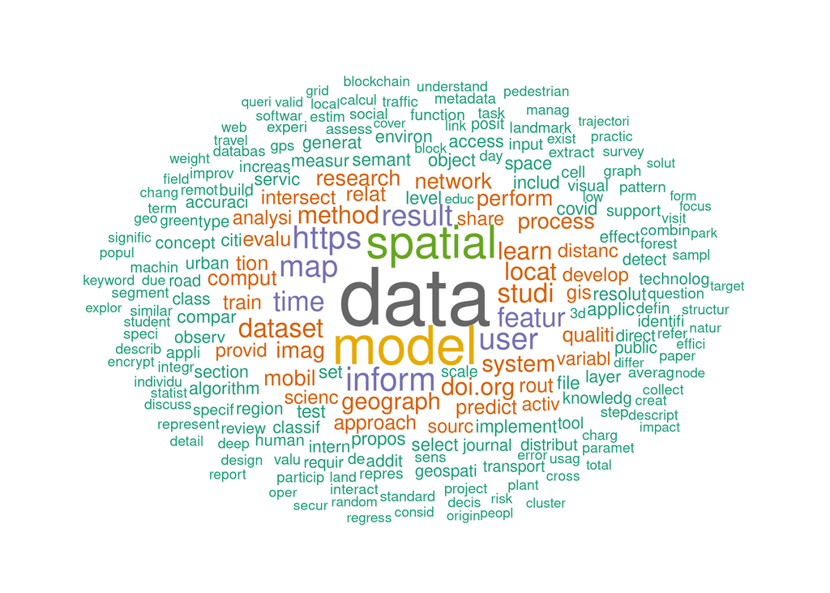

## Reproducible research-related keywords of all submissions

The following tables lists how often terms related to reproducible research appear in each document. The detection matches full words using regex option `\b`.

- reproduc (`reproduc.*`, reproducibility, reproducible, reproduce, reproduction)
- replic (`replicat.*`, i.e. replication, replicate)
- repeatab (`repeatab.*`, i.e. repeatability, repeatable)
- software
- (pseudo) code/script(s) [column name *code*]
- algorithm (`algorithm.*`, i.e. algorithms, algorithmic)
- process (`process.*`, i.e. processing, processes, preprocessing)
- data (`data.*`, i.e. dataset(s), database(s))
- result(s) (`results?`)
- repository(ies) (`repositor(y|ies)`)
- collaboration platforms (`git(hub|lab)`)

The following table highlights papers with the Data and Software Availability Section with italic font and grey background. The entries are sorted by descending sum of all keywords per paper.

| id | type | DASA | reproduc.. | replic.. | repeatab.. | code | software | algorithm(s) | (pre)process.. | data.* | result(s) | repository/ies | github/lab | all |
| --- | --- | --- | --- | --- | --- | --- | --- | --- | --- | --- | --- | --- | --- | --- |
| 015 | Full-paper submission | TRUE | 2 | 1 | 0 | 5 | 1 | 9 | 10 | 244 | 28 | 1 | 8 | 310 |
| 021 | Full-paper submission | FALSE | 0 | 1 | 0 | 3 | 8 | 22 | 14 | 198 | 10 | 8 | 0 | 264 |
| 023 | Full-paper submission | TRUE | 0 | 1 | 0 | 2 | 1 | 0 | 15 | 188 | 4 | 1 | 1 | 214 |
| 011 | Full-paper submission | TRUE | 0 | 0 | 0 | 2 | 1 | 9 | 9 | 133 | 23 | 2 | 0 | 180 |
| 008 | Full-paper submission | FALSE | 0 | 0 | 0 | 36 | 3 | 4 | 45 | 77 | 7 | 2 | 5 | 179 |
| 013 | Full-paper submission | TRUE | 2 | 0 | 0 | 1 | 4 | 9 | 6 | 98 | 30 | 0 | 2 | 153 |
| 020 | Full-paper submission | TRUE | 0 | 0 | 0 | 4 | 1 | 0 | 4 | 103 | 7 | 13 | 9 | 142 |
| 024 | Full-paper submission | TRUE | 0 | 1 | 0 | 2 | 1 | 25 | 16 | 69 | 8 | 0 | 5 | 128 |
| 055 | Short-paper submission | TRUE | 0 | 0 | 0 | 7 | 1 | 0 | 3 | 103 | 7 | 0 | 3 | 125 |
| 069 | Short-paper submission | FALSE | 0 | 0 | 0 | 0 | 4 | 5 | 5 | 95 | 3 | 0 | 0 | 112 |
| 027 | Full-paper submission | FALSE | 0 | 0 | 0 | 0 | 2 | 0 | 4 | 102 | 2 | 0 | 0 | 110 |
| 007 | Full-paper submission | TRUE | 1 | 0 | 0 | 1 | 2 | 2 | 9 | 68 | 20 | 0 | 2 | 106 |
| 005 | Full-paper submission | TRUE | 0 | 0 | 0 | 0 | 2 | 19 | 10 | 48 | 21 | 0 | 2 | 103 |
| 004 | Full-paper submission | TRUE | 0 | 0 | 0 | 0 | 2 | 2 | 9 | 67 | 20 | 0 | 0 | 101 |
| 014 | Full-paper submission | TRUE | 0 | 0 | 0 | 6 | 4 | 20 | 23 | 33 | 8 | 5 | 1 | 101 |
| 019 | Full-paper submission | TRUE | 6 | 1 | 0 | 0 | 3 | 7 | 6 | 51 | 12 | 0 | 7 | 94 |
| 057 | Short-paper submission | FALSE | 0 | 0 | 0 | 0 | 0 | 5 | 12 | 67 | 2 | 6 | 0 | 92 |
| 048 | Short-paper submission | TRUE | 0 | 0 | 0 | 2 | 3 | 4 | 18 | 47 | 14 | 1 | 0 | 90 |
| 012 | Full-paper submission | TRUE | 0 | 0 | 0 | 1 | 4 | 0 | 5 | 49 | 25 | 2 | 2 | 89 |
| 037 | Short-paper submission | FALSE | 0 | 0 | 0 | 1 | 1 | 1 | 2 | 81 | 3 | 0 | 0 | 89 |
| 016 | Full-paper submission | TRUE | 1 | 0 | 0 | 1 | 4 | 0 | 1 | 63 | 12 | 1 | 2 | 86 |
| 017 | Full-paper submission | TRUE | 0 | 0 | 0 | 3 | 1 | 1 | 6 | 48 | 11 | 5 | 7 | 83 |
| 032 | Short-paper submission | FALSE | 0 | 0 | 0 | 0 | 0 | 1 | 5 | 56 | 21 | 0 | 0 | 83 |
| 047 | Short-paper submission | FALSE | 0 | 0 | 0 | 1 | 0 | 7 | 3 | 32 | 39 | 1 | 0 | 83 |
| 077 | Short-paper submission | TRUE | 0 | 0 | 0 | 1 | 26 | 4 | 3 | 40 | 0 | 0 | 5 | 80 |
| 033 | Short-paper submission | FALSE | 0 | 1 | 0 | 1 | 2 | 6 | 4 | 52 | 9 | 2 | 1 | 78 |
| 030 | Short-paper submission | FALSE | 0 | 0 | 0 | 1 | 0 | 40 | 11 | 15 | 7 | 0 | 1 | 75 |
| 010 | Full-paper submission | TRUE | 0 | 0 | 0 | 0 | 2 | 2 | 5 | 39 | 22 | 0 | 1 | 72 |
| 003 | Full-paper submission | TRUE | 0 | 0 | 0 | 1 | 1 | 4 | 4 | 49 | 9 | 0 | 2 | 71 |
| 028 | Short-paper submission | TRUE | 0 | 0 | 0 | 1 | 1 | 17 | 2 | 35 | 9 | 1 | 2 | 69 |
| 070 | Short-paper submission | TRUE | 1 | 0 | 0 | 0 | 5 | 2 | 5 | 50 | 5 | 0 | 0 | 69 |
| 026 | Full-paper submission | TRUE | 0 | 0 | 0 | 0 | 6 | 2 | 3 | 50 | 4 | 0 | 1 | 67 |
| 064 | Short-paper submission | TRUE | 0 | 0 | 0 | 0 | 3 | 2 | 6 | 48 | 7 | 0 | 0 | 67 |
| 022 | Full-paper submission | TRUE | 0 | 0 | 0 | 1 | 2 | 3 | 8 | 13 | 37 | 0 | 1 | 66 |
| 056 | Short-paper submission | TRUE | 0 | 0 | 0 | 1 | 2 | 0 | 5 | 46 | 10 | 0 | 0 | 65 |
| 035 | Short-paper submission | FALSE | 0 | 0 | 0 | 4 | 2 | 1 | 1 | 53 | 2 | 0 | 0 | 63 |
| 041 | Short-paper submission | TRUE | 0 | 0 | 0 | 0 | 3 | 2 | 3 | 36 | 18 | 0 | 0 | 63 |
| 044 | Short-paper submission | FALSE | 1 | 0 | 0 | 2 | 2 | 1 | 9 | 37 | 10 | 1 | 0 | 63 |
| 045 | Short-paper submission | FALSE | 0 | 0 | 0 | 0 | 4 | 1 | 4 | 47 | 4 | 1 | 2 | 63 |
| 038 | Short-paper submission | FALSE | 0 | 0 | 0 | 1 | 0 | 0 | 32 | 21 | 2 | 0 | 0 | 56 |
| 065 | Short-paper submission | FALSE | 0 | 0 | 0 | 0 | 4 | 1 | 11 | 32 | 8 | 0 | 0 | 56 |
| 074 | Short-paper submission | TRUE | 0 | 0 | 0 | 1 | 1 | 3 | 13 | 14 | 21 | 0 | 1 | 55 |
| 076 | Short-paper submission | FALSE | 2 | 0 | 0 | 0 | 2 | 0 | 4 | 40 | 6 | 0 | 0 | 54 |
| 052 | Short-paper submission | TRUE | 0 | 0 | 0 | 0 | 2 | 0 | 5 | 40 | 2 | 0 | 0 | 50 |
| 006 | Full-paper submission | TRUE | 0 | 0 | 0 | 1 | 2 | 16 | 5 | 10 | 14 | 0 | 0 | 49 |
| 034 | Short-paper submission | TRUE | 0 | 0 | 0 | 0 | 3 | 2 | 3 | 27 | 10 | 1 | 2 | 49 |
| 062 | Short-paper submission | FALSE | 0 | 0 | 0 | 0 | 6 | 1 | 13 | 26 | 2 | 0 | 0 | 48 |
| 066 | Short-paper submission | FALSE | 0 | 0 | 0 | 1 | 0 | 0 | 0 | 41 | 4 | 0 | 1 | 47 |
| 078 | Short-paper submission | FALSE | 0 | 0 | 0 | 0 | 1 | 3 | 13 | 24 | 6 | 0 | 0 | 47 |
| 029 | Short-paper submission | FALSE | 1 | 0 | 0 | 2 | 1 | 1 | 7 | 28 | 2 | 0 | 0 | 42 |
| 036 | Short-paper submission | TRUE | 0 | 0 | 0 | 0 | 2 | 0 | 3 | 22 | 14 | 0 | 0 | 42 |
| 081 | Short-paper submission | FALSE | 0 | 0 | 0 | 1 | 0 | 0 | 6 | 30 | 4 | 0 | 1 | 42 |
| 075 | Short-paper submission | FALSE | 0 | 0 | 0 | 0 | 0 | 0 | 5 | 36 | 0 | 0 | 0 | 41 |
| 009 | Full-paper submission | TRUE | 0 | 0 | 0 | 1 | 7 | 0 | 10 | 19 | 1 | 0 | 0 | 39 |
| 050 | Short-paper submission | FALSE | 0 | 0 | 0 | 0 | 0 | 0 | 7 | 22 | 10 | 0 | 0 | 39 |
| 073 | Short-paper submission | TRUE | 0 | 0 | 0 | 0 | 1 | 0 | 5 | 29 | 1 | 0 | 1 | 38 |
| 039 | Short-paper submission | TRUE | 0 | 1 | 0 | 0 | 2 | 0 | 12 | 8 | 10 | 0 | 0 | 34 |
| 063 | Short-paper submission | FALSE | 0 | 0 | 0 | 0 | 0 | 0 | 0 | 28 | 4 | 0 | 0 | 32 |
| 018 | Full-paper submission | FALSE | 0 | 0 | 0 | 1 | 3 | 0 | 5 | 4 | 18 | 0 | 0 | 31 |
| 051 | Short-paper submission | FALSE | 0 | 0 | 0 | 0 | 1 | 0 | 0 | 19 | 11 | 0 | 0 | 31 |
| 049 | Short-paper submission | FALSE | 0 | 0 | 0 | 0 | 0 | 3 | 1 | 10 | 12 | 0 | 0 | 26 |
| 071 | Short-paper submission | TRUE | 0 | 0 | 0 | 4 | 2 | 4 | 5 | 7 | 0 | 1 | 1 | 25 |
| 072 | Short-paper submission | FALSE | 0 | 0 | 0 | 2 | 10 | 0 | 1 | 8 | 4 | 0 | 0 | 25 |
| 080 | Short-paper submission | FALSE | 0 | 0 | 0 | 3 | 1 | 0 | 0 | 19 | 2 | 0 | 0 | 25 |
| 068 | Short-paper submission | TRUE | 0 | 0 | 0 | 0 | 1 | 3 | 1 | 10 | 8 | 0 | 0 | 24 |
| 067 | Short-paper submission | FALSE | 0 | 0 | 0 | 0 | 0 | 3 | 2 | 5 | 12 | 0 | 0 | 22 |
| 046 | Short-paper submission | FALSE | 0 | 0 | 0 | 0 | 0 | 4 | 8 | 3 | 1 | 0 | 0 | 16 |
| 054 | Short-paper submission | FALSE | 0 | 0 | 0 | 0 | 1 | 0 | 0 | 12 | 3 | 0 | 0 | 16 |
| 079 | Short-paper submission | FALSE | 0 | 0 | 0 | 0 | 1 | 0 | 3 | 8 | 4 | 0 | 0 | 16 |
| 058 | Short-paper submission | FALSE | 1 | 0 | 0 | 0 | 0 | 0 | 0 | 8 | 3 | 0 | 0 | 12 |
| 043 | Short-paper submission | FALSE | 0 | 0 | 0 | 0 | 0 | 1 | 3 | 2 | 4 | 0 | 0 | 10 |
| 061 | Short-paper submission | FALSE | 0 | 0 | 0 | 0 | 0 | 0 | 0 | 5 | 5 | 0 | 0 | 10 |
| 031 | Short-paper submission | FALSE | 0 | 0 | 0 | 0 | 0 | 0 | 1 | 8 | 0 | 0 | 0 | 9 |
| 053 | Short-paper submission | FALSE | 0 | 0 | 0 | 1 | 3 | 0 | 4 | 1 | 0 | 0 | 0 | 9 |
| 059 | Short-paper submission | FALSE | 0 | 0 | 0 | 0 | 0 | 1 | 0 | 5 | 0 | 0 | 0 | 6 |
| 040 | Short-paper submission | NA | NA | NA | NA | NA | NA | NA | NA | NA | NA | NA | NA | NA |
| 060 | Short-paper submission | NA | NA | NA | NA | NA | NA | NA | NA | NA | NA | NA | NA | NA |
| Total |  | T:36\|F:39 | NA | NA | NA | NA | NA | NA | NA | NA | NA | NA | NA | NA |

## Accepted full papers

### Full paper decisions

There is “accept” and “conditionally accept” (after second review)!

| decision | count |
| --- | --- |
| ACCEPT | 24 |

| id | authors | title | information | paper | assigment | update | time | decision | type | submission_id | file | dasa_text |
| --- | --- | --- | --- | --- | --- | --- | --- | --- | --- | --- | --- | --- |
| 003 | Pengxiang Zhao, Aoyong Li, Petter Pilesjö and Ali Mansourian | A machine learning based approach for predicting usage efficiency of shared e-scooters using vehicle availability data | https://easychair.org/conferences/submission_view?a=28425498;submission=5833597 | https://easychair.org/conferences/submission_download?a=28425498;submission=5833597;upload=119385 | NA | NA | Feb 03, 15:31 | ACCEPT | Full-paper submission | 5833597 | /home/rstudio/submissions/003.pdf | Data and software availability In this study, the vehicle availability data of e-scooter shar- ing services in Stockholm, Sweden was collected from one micro-mobility operator that has a high market s… |
| 004 | Hiroyuki Kaneko and Toshihiro Osaragi | Classifying pedestrian trajectories by Machine learning using laser sensor data | https://easychair.org/conferences/submission_view?submission=5836890;a=28425498 | https://easychair.org/conferences/submission_download?submission=5836890;upload=119385;a=28425498 | NA | NA | Feb 07, 01:53 | ACCEPT | Full-paper submission | 5836890 | /home/rstudio/submissions/004.pdf | Data and Software Availability The hospital survey was conducted under the condition that observation data was not made public, so data cannot be shared. The software developed in this study cannot be… |
| 005 | Jean-Marie Favreau and Jérémy Kalsron | What are intersections for pedestrian users? | https://easychair.org/conferences/submission_view?a=28425498;submission=5838467 | https://easychair.org/conferences/submission_download?a=28425498;upload=119385;submission=5838467 | NA | NA | Feb 07, 22:23 | ACCEPT | Full-paper submission | 5838467 | /home/rstudio/submissions/005.pdf | Data and software availability Our method was applied to datasets downloaded and used without any modification in February 2022 from the Open- StreetMap collaborative database5, available under the Op… |
| 006 | Eva Nuhn, Franziska König and Sabine Timpf | “Landmark Route”: A Comparison to the Shortest Route | https://easychair.org/conferences/submission_view?submission=5838884;a=28425498 | https://easychair.org/conferences/submission_download?a=28425498;upload=119385;submission=5838884 | NA | NA | Feb 08, 07:25 | ACCEPT | Full-paper submission | 5838884 | /home/rstudio/submissions/006.pdf | Data and Software Availability Section The survey was answered anonymously in the Survey123 App (Survey123, 2021). The result of the survey is a downloadable .csv-file. All statistical analyses, which… |
| 007 | Nina Wiedemann, Henry Martin and Martin Raubal | Unlocking social network analysis methods for studying human mobility | https://easychair.org/conferences/submission_view?submission=5854892;a=28425498 | https://easychair.org/conferences/submission_download?a=28425498;upload=119385;submission=5854892 | NA | NA | Feb 16, 11:00 | ACCEPT | Full-paper submission | 5854892 | /home/rstudio/submissions/007.pdf | Data and software availability The source code to reproduce our results on the pub- lic Foursquare dataset is available at https://github.com/ NinaWie/network_analysis. Acknowledgements Many thanks to… |
| 008 | Lasith Niroshan and James Carswell | Machine Learning with Kay | https://easychair.org/conferences/submission_view?a=28425498;submission=5856283 | https://easychair.org/conferences/submission_download?upload=119385;submission=5856283;a=28425498 | NA | NA | Feb 17, 13:13 | ACCEPT | Full-paper submission | 5856283 | /home/rstudio/submissions/008.pdf | NA |
| 009 | Frederika Welle Donker, Bastiaan Van Loenen, Carsten Keßler, Natalie Küppers, Mark Panek, Ali Mansourian, Pengxiang Zhao, Glenn Vancauwenberghe, Hrvoje Tomić and Karlo Kević | Showcase of Active Learning and Teaching Practices in Spatial Data Infrastructure (SDI) Education | https://easychair.org/conferences/submission_view?submission=5862956;a=28425498 | https://easychair.org/conferences/submission_download?a=28425498;upload=119385;submission=5862956 | NA | NA | Feb 21, 15:07 | ACCEPT | Full-paper submission | 5862956 | /home/rstudio/submissions/009.pdf | Data and software availability No data or code was collected, developed, or used in this work. Our research generated a database of literature related to open SDIs and ALT methodologies and evaluation… |
| 010 | Haojun Cai, Yanan Xin, Henry Martin and Martin Raubal | Optimizing Electric Vehicle Charging Schedules Based on Probabilistic Forecast of Individual Mobility | https://easychair.org/conferences/submission_view?submission=5863719;a=28425498 | https://easychair.org/conferences/submission_download?a=28425498;upload=119385;submission=5863719 | NA | NA | Feb 22, 00:40 | ACCEPT | Full-paper submission | 5863719 | /home/rstudio/submissions/010.pdf | Data and Software Availability EV car data and user data cannot be made available due to the non-disclosure agreement with participants. Electricity spot prices are available for purchase from EPEX Sp… |
| 011 | Stefania Zourlidou, Jens Golze and Monika Sester | Traffic Regulation Recognition using Crowd-Sensed GPS and Map Data: a Hybrid Approach | https://easychair.org/conferences/submission_view?a=28425498;submission=5864439 | https://easychair.org/conferences/submission_download?upload=119385;submission=5864439;a=28425498 | NA | NA | Feb 22, 12:34 | ACCEPT | Full-paper submission | 5864439 | /home/rstudio/submissions/011.pdf | Data and Software Availability The groundtruth map from the Chicago dataset, is accessi- ble in a public repository (Zourlidou and Golze, 2022) and has an open data licence. The Chicago trajectory dat… |
| 012 | Ditsuhi Iskandaryan, Silvana Di Sabatino, Francisco Ramos and Sergio Trilles | Exploratory Analysis and Feature Selection for the Prediction of Nitrogen Dioxide | https://easychair.org/conferences/submission_view?a=28425498;submission=5864480 | https://easychair.org/conferences/submission_download?a=28425498;upload=119385;submission=5864480 | NA | NA | Feb 22, 13:15 | ACCEPT | Full-paper submission | 5864480 | /home/rstudio/submissions/012.pdf | Data and Software Availability This section introduces the datasets that have been used in the analyses. The datasets used in this work are NO2 (µg/m3), meteorological data and traffic data from the p… |
| 013 | Marina Georgati, João Monteiro, Bruno Martins and Carsten Keßler | Spatial Disaggregation of Population Subgroups Leveraging Self-Trained Multi-Output Gradient Boosted Regression Trees | https://easychair.org/conferences/submission_view?submission=5864635;a=28425498 | https://easychair.org/conferences/submission_download?a=28425498;submission=5864635;upload=119385 | NA | NA | Feb 22, 15:24 | ACCEPT | Full-paper submission | 5864635 | /home/rstudio/submissions/013.pdf | data and software availability. 2 Related Work This section describes traditional methods for spatial data disaggregation, followed by a survey of recent approaches. 2.1 Seminal Spatial Disaggregation… |
| 014 | Syed Mehtab Alam, Elena Arsevska, Mathieu Roche and Maguelonne Teisseire | GeoXTag: Relative Spatial Information Extraction and Tagging of Unstructured Text | https://easychair.org/conferences/submission_view?submission=5864717;a=28425498 | https://easychair.org/conferences/submission_download?upload=119385;submission=5864717;a=28425498 | NA | NA | Feb 22, 16:13 | ACCEPT | Full-paper submission | 5864717 | /home/rstudio/submissions/014.pdf | Data and Software Availability The whole workflow is divided into two main components, i.e., 1) GeoX - Relative Spatial Information Extraction and 2) GeoX - Relative Spatial Information Tagging. The s… |
| 015 | Marie-Dominique Van Damme and Ana-Maria Olteanu-Raimond | A method to produce metadata describing and assessing the quality of spatial landmark datasets in mountain area | https://easychair.org/conferences/submission_view?a=28425498;submission=5865024 | https://easychair.org/conferences/submission_download?submission=5865024;upload=119385;a=28425498 | NA | NA | Feb 22, 21:40 | ACCEPT | Full-paper submission | 5865024 | /home/rstudio/submissions/015.pdf | Software and Data Availability 2.4.1 Methods and code availability The data matching algorithm is coded in java and is available on github: https://github.com/umrlastig/ MultiCriteriaMatching Data qua… |
| 016 | Hyesop Shin, Costanza Cagnina and Anahid Basiri | The Impact of Built Environment on Bike Commuting: Utilising Strava Bike Data and Geographically Weighted Models | https://easychair.org/conferences/submission_view?a=28425498;submission=5865026 | https://easychair.org/conferences/submission_download?submission=5865026;upload=119385;a=28425498 | NA | NA | Feb 22, 21:46 | ACCEPT | Full-paper submission | 5865026 | /home/rstudio/submissions/016.pdf | Data and Software Availability Cycling: The University of Glasgow’s Urban Big Data Centre provided Strava data for 2017 and 2018 (https: //www.ubdc.ac.uk). The data contains three products: Nodes, Edg… |
| 017 | Tom Niers, Jan Stenkamp, Nick Pascal Jakuschona, Thomas Bartoschek and Sven Schade | Benchmarking Invasive Alien Species Image Recognition Models for a Citizen Science Based Spatial Distribution Monitoring | https://easychair.org/conferences/submission_view?a=28425498;submission=5865034 | https://easychair.org/conferences/submission_download?upload=119385;submission=5865034;a=28425498 | NA | NA | Feb 22, 21:58 | ACCEPT | Full-paper submission | 5865034 | /home/rstudio/submissions/017.pdf | Data and Software Availability Research code supporting this document is accessible on GitHub. All repositories are available in the GitHub orga- nization EibSReM (Jakuschona et al., 2022b). The three… |
| 018 | Thomas Bartoschek and Schwering Angela | Geotechnology-based Spatial Learning: The Effects on Spatial Abilities and Sketch Maps in an Inter-Cultural Study | https://easychair.org/conferences/submission_view?submission=5865062;a=28425498 | https://easychair.org/conferences/submission_download?submission=5865062;upload=119385;a=28425498 | NA | NA | Feb 22, 22:47 | ACCEPT | Full-paper submission | 5865062 | /home/rstudio/submissions/018.pdf | NA |
| 019 | Zilong Liu, Krzysztof Janowicz, Ling Cai, Rui Zhu, Gengchen Mai and Meilin Shi | Geoparsing: Solved or Biased? An Evaluation of Geographic Biases in Geoparsing | https://easychair.org/conferences/submission_view?submission=5865075;a=28425498 | https://easychair.org/conferences/submission_download?submission=5865075;upload=119385;a=28425498 | NA | NA | Feb 22, 23:00 | ACCEPT | Full-paper submission | 5865075 | /home/rstudio/submissions/019.pdf | Data and Software Availability The toponym recognition and toponym resolution models we used are all publicly available as described in Section 3.1. The evaluation corpora and data patches used in our… |
| 020 | Rui Zhu, Krzysztof Janowicz, Gengchen Mai, Ling Cai and Meilin Shi | COVID-Forecast-Graph: An Open Knowledge Graph for Consolidating COVID-19 Forecasts and Economic Indicators via Place and Time | https://easychair.org/conferences/submission_view?submission=5865082;a=28425498 | https://easychair.org/conferences/submission_download?a=28425498;upload=119385;submission=5865082 | NA | NA | Feb 22, 23:16 | ACCEPT | Full-paper submission | 5865082 | /home/rstudio/submissions/020.pdf | Data and Software Availability The COVID-SO ontology, as well as the generated knowl- edge graph - COVID-Forecast-Graph - are available at http s://github.com/zhurui0509/COVID-Forecast-Graph. Ad- diti… |
| 021 | Pankajeshwara Nand Sharma, Michael Govorov and Nick Rollings | A Usable Encryption Solution for File-based Spatial Data Within a Database File System | https://easychair.org/conferences/submission_view?submission=5868024;a=28425498 | https://easychair.org/conferences/submission_download?a=28425498;submission=5868024;upload=119385 | NA | NA | Feb 25, 03:58 | ACCEPT | Full-paper submission | 5868024 | /home/rstudio/submissions/021.pdf | NA |
| 022 | Yousef Qamaz, Angela Schwering and Janina Bistron | Experimental evaluation of using BLE beacon for outdoor positioning in GPS-denied environment | https://easychair.org/conferences/submission_view?a=28425498;submission=5889379 | https://easychair.org/conferences/submission_download?a=28425498;upload=119385;submission=5889379 | NA | NA | Mar 08, 18:14 | ACCEPT | Full-paper submission | 5889379 | /home/rstudio/submissions/022.pdf | Data and Software Availability The source code of our proposed system is accessible via: https://github.com/origami-team/origami under MIT license. Data is available upon request. References Benford, … |
| 023 | Arun Sharma, Majid Farhadloo, Yan Li, Aditya Kulkarni, Jayant Gupta and Shashi Shekhar | Understanding COVID-19 Effects on Mobility: A Community-Engaged Approach | https://easychair.org/conferences/submission_view?submission=5889451;a=28425498 | https://easychair.org/conferences/submission_download?upload=119385;submission=5889451;a=28425498 | NA | NA | Mar 08, 19:03 | ACCEPT | Full-paper submission | 5889451 | /home/rstudio/submissions/023.pdf | Data and Software Availability Safegraph was purchased and can be remotely accessed. The compiled dataset cannot be redistributed due to licens- ing restrictions. Figures 7-14 and Figures 16-17 can be… |
| 024 | Guoray Cai and Yimu Pan | Understanding the Imperfection of 3D point Cloud and Semantic Segmentation algorithms for 3D Models of Indoor Environment | https://easychair.org/conferences/submission_view?submission=5889639;a=28425498 | https://easychair.org/conferences/submission_download?a=28425498;submission=5889639;upload=119385 | NA | NA | Mar 08, 23:10 | ACCEPT | Full-paper submission | 5889639 | /home/rstudio/submissions/024.pdf | Data and software availability The 3D indoor point cloud data used in this pa- per can be requested from S3DIS project website (http://buildingparser.stanford.edu/dataset.html). Point- Net++ semantic … |
| 026 | Krzysztof Janowicz, Rui Zhu, Grant McKenzie, Judith Verstegen, Bruno Martins and Ling Cai | Six GIScience Ideas That Must Die | https://easychair.org/conferences/submission_view?submission=5889979;a=28425498 | https://easychair.org/conferences/submission_download?a=28425498;upload=119385;submission=5889979 | NA | NA | Mar 09, 08:03 | ACCEPT | Full-paper submission | 5889979 | /home/rstudio/submissions/026.pdf | Data and Software Availability This paper has no directly associated data or software. Rel- evant data/software are described in the referenced papers. Acknowledgements. We certify that there is no ac… |
| 027 | Giedrė Beconytė, Andrius Balčiūnas, Inga Andriuškevičiūtė and Živilė Jakubkaitė | Lithuanian spatial information infrastructure: 20 years of evolution, milestones, costs and benefits | https://easychair.org/conferences/submission_view?a=28425498;submission=5937396 | https://easychair.org/conferences/submission_download?submission=5937396;upload=119385;a=28425498 | NA | NA | Apr 05, 19:06 | ACCEPT | Full-paper submission | 5937396 | /home/rstudio/submissions/027.pdf | NA |

### Which accepted papers do still not hava a DASA section

```r
review_data %>%
  filter(type == "Full-paper submission") %>%
  dplyr::filter(decision == "ACCEPT", is.na(`dasa_text`)) %>%
  select(id, title, authors)
```

```
## # A tibble: 4 × 3
##   id    title                                                            authors
##   <chr> <chr>                                                            <chr>
## 1 008   Machine Learning with Kay                                        Lasith…
## 2 018   Geotechnology-based Spatial Learning: The Effects on Spatial Ab… Thomas…
## 3 021   A Usable Encryption Solution for File-based Spatial Data Within… Pankaj…
## 4 027   Lithuanian spatial information infrastructure: 20 years of evol… Giedrė…
```

### Which papers have a link to the reproducibility review

*Does not work reliably yet.* These are the papers where the reproducibility review resulted in at least partially successful reproduction.

```r
# hope that at least on of the phrases is not stretched across multiple spaces
report_pattern <- regex("(AGILE[:space:]reproducibility[:space:]review|reproducibility[:space:]report)", ignore_case = TRUE)
tidy_texts <- tidy_texts %>%
  mutate(has_report = str_detect(tidy_texts$text, pattern = report_pattern))

report_count <- tidy_texts %>% filter(has_report) %>% nrow()

excerpt_length <- 300
report_texts <- tidy_texts %>%
  filter(has_report) %>%
  mutate(report_start = str_locate(.data$text, pattern = report_pattern)[,1]) %>%
  mutate(report_text = str_sub(.data$text, start = report_start, end = report_start + excerpt_length)) %>%
  select(id, type, report_text)

report_texts %>%
    arrange(id) %>%
    kable() %>%
    kable_styling("striped") %>%
    scroll_box(height = "320px")
```

| id | type | report_text |
| --- | --- | --- |

## Reproducibility reviews

### About

The assignment of reviews is done via a privately shared spreadsheet, to handle potential non-public comments. The main outcome of the reviews is a *report*, which is published in individual OSF projects as components of the [OSF project for the reproducibility reviews 2022](https://osf.io/r5w79/). The report should be based on a template from this repository in `report-template`.

### Prepare data for reviewers

#### Overview and files

Reproducibility reviewers have access to the submission and reviews through EasyChair. The following snippets helpt to create a shared Google Spreadsheet to manage the status of reproductions.

```r
review_data_csv_file <- file.path(review_files_path, "review_data.csv")
```

1. Write paper metadata (ID, decision, title) to a CSV file /home/rstudio/review-material/review_data.csv
2. **Manually** [import the paper metadata into the spreadsheet](https://www.tillerhq.com/how-to-import-csv-into-a-google-spreadsheet/) (Select cell `A1` then “File” > “Import” > “Import File” > “My Drive” then search for `review_data` and find `review_data.csv` then select the file > “Replace data at selected cell” and click “Import data”)

#### Reviewer comments

```
## 003  --  003
## 004  --  004
## 005  --  005
## 006  --  006
## 007  --  007
## 008  --  008
## 009  --  009
## 010  --  001
```

```
## 011  --  001
```

```
## 012  --  001
```

```
## 013  --  001
```

```
## 014  --  001
```

```
## 015  --  001
```

```
## 016  --  001
```

```
## 017  --  001
```

```
## 018  --  001
```

```
## 019  --  001
```

```
## 020  --  002
```

```
## 021  --  002
```

```
## 022  --  002
```

```
## 023  --  002
```

```
## 024  --  002
```

```
## 026  --  002
```

```
## 027  --  002
```

#### Author contacts

```
## 003  --  003
## 004  --  004
## 005  --  005
## 006  --  006
## 007  --  007
## 008  --  008
## 009  --  009
## 010  --  001
```

```
## 011  --  001
```

```
## 012  --  001
```

```
## 013  --  001
```

```
## 014  --  001
```

```
## 015  --  001
```

```
## 016  --  001
```

```
## 017  --  001
```

```
## 018  --  001
```

```
## 019  --  001
```

```
## 020  --  002
```

```
## 021  --  002
```

```
## 022  --  002
```

```
## 023  --  002
```

```
## 024  --  002
```

```
## 026  --  002
```

```
## 027  --  002
```

#### Upload submissions, reviews, and author contacts, to share

[output not shown]

[output not shown]

[output not shown]

[output not shown]

[output not shown]

[output not shown]

[output not shown]

[output not shown]

[output not shown]

[output not shown]

[output not shown]

[output not shown]

[output not shown]

[output not shown]

[output not shown]

[output not shown]

[output not shown]

[output not shown]

[output not shown]

[output not shown]

[output not shown]

[output not shown]

[output not shown]

[output not shown]

[output not shown]

[output not shown]

[output not shown]

[output not shown]

[output not shown]

[output not shown]

[output not shown]

[output not shown]

[output not shown]

[output not shown]

[output not shown]

[output not shown]

[output not shown]

[output not shown]

[output not shown]

[output not shown]

[output not shown]

[output not shown]

[output not shown]

[output not shown]

[output not shown]

[output not shown]

[output not shown]

[output not shown]

[output not shown]

[output not shown]

[output not shown]

[output not shown]

[output not shown]

[output not shown]

[output not shown]

[output not shown]

[output not shown]

[output not shown]

[output not shown]

[output not shown]

[output not shown]

[output not shown]

[output not shown]

[output not shown]

[output not shown]

[output not shown]

[output not shown]

[output not shown]

[output not shown]

[output not shown]

[output not shown]

[output not shown]

[output not shown]

[output not shown]

[output not shown]

[output not shown]

[output not shown]

[output not shown]

[output not shown]

[output not shown]

[output not shown]

[output not shown]

[output not shown]

[output not shown]

[output not shown]

[output not shown]

[output not shown]

[output not shown]

[output not shown]

[output not shown]

[output not shown]

[output not shown]

[output not shown]

[output not shown]

[output not shown]

[output not shown]

[output not shown]

[output not shown]

[output not shown]

[output not shown]

[output not shown]

[output not shown]

[output not shown]

[output not shown]

[output not shown]

[output not shown]

[output not shown]

[output not shown]

[output not shown]

[output not shown]

[output not shown]

[output not shown]

[output not shown]

[output not shown]

[output not shown]

[output not shown]

[output not shown]

[output not shown]

[output not shown]

[output not shown]

[output not shown]

[output not shown]

[output not shown]

[output not shown]

[output not shown]

[output not shown]

[output not shown]

[output not shown]

[output not shown]

[output not shown]

[output not shown]

[output not shown]

[output not shown]

[output not shown]

[output not shown]

[output not shown]

[output not shown]

[output not shown]

[output not shown]

[output not shown]

[output not shown]

[output not shown]

[output not shown]

[output not shown]

[output not shown]

[output not shown]

[output not shown]

[output not shown]

[output not shown]

[output not shown]

[output not shown]

[output not shown]

[output not shown]

[output not shown]

[output not shown]

[output not shown]

[output not shown]

[output not shown]

[output not shown]

[output not shown]

[output not shown]

[output not shown]

[output not shown]

[output not shown]

[output not shown]

[output not shown]

[output not shown]

[output not shown]

[output not shown]

[output not shown]

[output not shown]

[output not shown]

[output not shown]

[output not shown]

[output not shown]

[output not shown]

[output not shown]

[output not shown]

[output not shown]

[output not shown]

[output not shown]

[output not shown]

[output not shown]

[output not shown]

[output not shown]

[output not shown]

[output not shown]

[output not shown]

[output not shown]

[output not shown]

[output not shown]

[output not shown]

[output not shown]

[output not shown]

[output not shown]

[output not shown]

[output not shown]

[output not shown]

[output not shown]

[output not shown]

[output not shown]

[output not shown]

[output not shown]

[output not shown]

[output not shown]

[output not shown]

[output not shown]

[output not shown]

[output not shown]

[output not shown]

[output not shown]

[output not shown]

[output not shown]

[output not shown]

[output not shown]

[output not shown]

[output not shown]

[output not shown]

[output not shown]

[output not shown]

[output not shown]

[output not shown]

[output not shown]

[output not shown]

[output not shown]

[output not shown]

[output not shown]

[output not shown]

[output not shown]

[output not shown]

[output not shown]

[output not shown]

[output not shown]

[output not shown]

[output not shown]

[output not shown]

[output not shown]

[output not shown]

[output not shown]

[output not shown]

[output not shown]

[output not shown]

[output not shown]

[output not shown]

[output not shown]

[output not shown]

[output not shown]

[output not shown]

[output not shown]

[output cut: 41 more lines]

[output not shown]

### Reproducibility reviewer instructions

1. Familiarise yourself with the [AGILE Reproducibility Review Process](https://docs.google.com/document/d/1JHCQV7GP3YkKwp0Nii3dt3p3Y45hU56Xz2cr-xJVz34/edit#heading=h.oheeg2s92zdm); the following steps are just tl;dr version
2. Take a look at the [review report template](https://github.com/reproducible-agile/reviews-2022/blob/master/report-template/reproreview-template.Rmd) - even if you’re not using it, it gives you guidance
3. Go to the [Discoure forum discussion for reproducibility reviewers](https://discourse.agile-online.org/c/repro-review-2022/8) and find your assignments
4. Conduct your reproducibility review and write the report
   - Don’t forget to take a look at the scientific reviews for comments on reproducibility; do *not* worry about the science or read the full paper, unless it really interests you
   - Check the authors and their affiliations of the submission - is there a relation (e.g., former colleague, current supervisor) that may be seen as inappropriate for you as a reproducibility reviewer? Is there a conflict of interest? If so, please contact the reproducibility chair, and ask in the Discourse forum if another reproducibility reviewer would be available to switch assignments
   - If code is available on GitHub/Lab, please fork the project into the [Reproducible AGILE organisation](https://github.com/reproducible-agile/) respectively the [GitLab subgroup “reviews”](https://gitlab.com/reproducible-agile/reviews) and immediately “archive” the project so that it becomes read-only ([instructions GitHub](https://docs.github.com/en/github/creating-cloning-and-archiving-repositories/about-archiving-repositories), [instructions for GitLab](https://docs.gitlab.com/ee/user/project/settings/#archiving-a-project)); ask Daniel to get the permissions for the organisations
   - If need be, limit the review scope, e.g. reproduce only a specific figure; the reproducibility review should not take you longer (not counting computation time) than a scientific review, and even computation times should not expand longer than a working day
5. Send the report to the original authors of the paper and add the reproducibility chair in CC, see template below;
6. Add a new component to the [OSF project for 2022 reproducibility reviews](https://osf.io/r5w79/)
   - Use the European storage location, “Frankfurt”
   - Name the component `Reproducibility review of: FULL PAPER TITLE`
   - Add all contributors to the project
   - Add the to be expected DOI to your report
   - Keep the project **private** until the publication of the paper (we don’t want to announce anything that is not our place to announce)
   - Wait for final paper citation from publisher and add it to the report
   - Upload the report and supplemental material created by you, if suitable also the original material (add `LICENSE.md` and licensing information in the OSF project description in that case)
   - Publish the component and mint a DOI
   - Upload a PDF of your report and any useful supplemental files
7. Add link to the OSF project in the master spreadsheet

### Author contact templates

#### Reminder DASA by reproducibility chair

```
Dear <AUTHORS>,

I'm contacting you as the corresponding author of the paper "<TITLE>" submitted to AGILE 2022.

In my screening of accepted papers I saw that your submission does not include a Data and Software Availability ("DASA") section. Please note that a DASA section with precisely that name is mandatory. Furthermore a successful reproduction of your workflow would be an advertisement for your paper.

Please provide the DASA section by the end of the week so we can start the reproducibility review.

Regards,
Daniel

AGILE Reproducibility Committee Chair 2022
```

#### Reminder DASA

```
Dear <AUTHORS>,

I'm contacting you as the corresponding author of the paper "<TITLE>" submitted to AGILE 2022.
I'm the reproducibility reviewer your paper has been assigned to.

The scientific reviewers have noted that your paper does not include a Data and Software Availability ("DASA") section.
Please note that a DASA section is mandatory and successful reproduction of your workflow would be an advertisement for your paper.

Please provide the DASA section by <DEADLINE> so we can start the reproducibility review.

Regards,
<NAME>

AGILE Reproducibility Committee 2022
```

#### Reminder DASA + synthetic data for proprietary data

[output not shown]

#### Share report draft

[output not shown]

#### Report published

```
Dear <AUTHORS>,

thank you for your participation in a real open science endeavour!

The reproducibility review report on your paper is now published at DOI URL HERE.

Please don't hesitate to get in touch with Daniel Nüst (CC'ed), AGILE conference's Reproducibility Chair, if you have any questions.

Best regards,
<NAME>

AGILE Reproducibility Committee 2022
```

## Colophon

This document is licensed under a [Creative Commons Attribution 4.0 International License](https://creativecommons.org/licenses/by/4.0/). All contained code is licensed under the [Apache License 2.0](https://choosealicense.com/licenses/apache-2.0/).

**The used MRAN snapshot is https://packagemanager.rstudio.com/cran/__linux__/focal/latest**.